# FIgureYa31lasso

小丫画图出品

2018-8-20

微信ID: epigenomics E-mail: figureya@126.com

lasso代码作者：小M

画图函数修改：小丫

## 需求描述

画出paper中的lasso回归图，给出图中线所对应的基因顺序。

将纳入signature的变量拟合成一个变量，作为nomogram的输入。

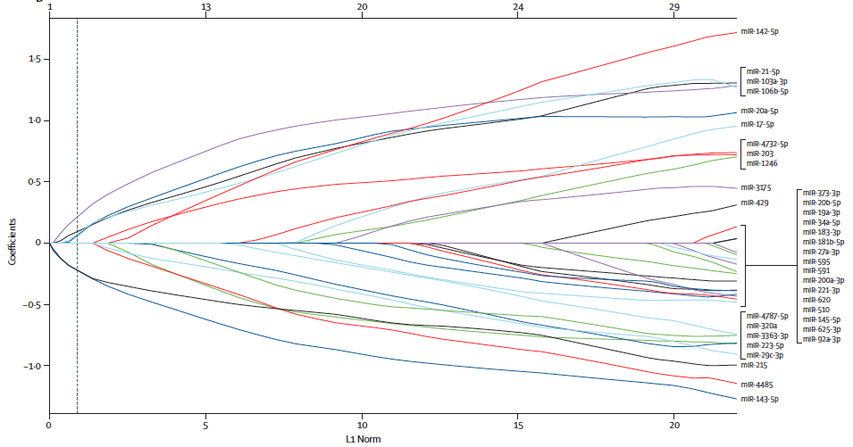

出自https://linkinghub.elsevier.com/retrieve/pii/S1470-2045(13)70491-1

## 应用场景

筛选差异基因之后，进一步筛选有预后意义的基因，组成基因表达signature。

LASSO对于高维度、强相关、小样本的生存资料数据较为适用。

## 输入数据

输入文件有两个，一个是生存信息`easy_input_suv.csv`，一个是基因表达矩阵`easy_input_exp.csv`。

`easy_input_suv.csv`，生存信息，至少包含三列，分别为patient IDs、follow up time、life status

`easy_input_exp.csv`，基因表达矩阵，每行一个基因，每列一个patient，跟`suv.csv`里的`patient ID`一致。

```r
myexpr <- read.csv("easy_input_exp.csv", header = T,row.names = 1)
myexpr[1:3,1:4]
```

```
##       PATIENT1 PATIENT2 PATIENT3 PATIENT4
## mir-1    7.288    7.796    6.026    9.304
## mir-2    9.600    9.830    7.820    9.000
## mir-3    6.610    7.695    5.615    5.205
```

```r
mysurv <- read.csv("easy_input_suv.csv", header = T,row.names = 1)
head(mysurv)
```

```
##            months status
## PATIENT1 47.23333      0
## PATIENT2 73.90000      0
## PATIENT3 53.60000      0
## PATIENT4 39.90000      0
## PATIENT5 51.86667      0
## PATIENT6 47.16667      0
```

```r
#检查样品信息跟表达量矩阵的样品是否一致
if (all(colnames(myexpr) %in% rownames(mysurv))){
  warning("两个文件的patient ID是一致的")
} else{
  warning("两个文件的patient ID不一致")
}
```

## 开始画图

采用R包`glmnet`，它是目前最好用的拟合广义线性模型的R包，由`LASSO` 回归的发明人，斯坦福统计学家 Trevor Hastie 领衔开发。

```r
#install.packages("glmnet")
#install.packages("survival")
library("glmnet")
library("survival")
```

### 算出lambda值

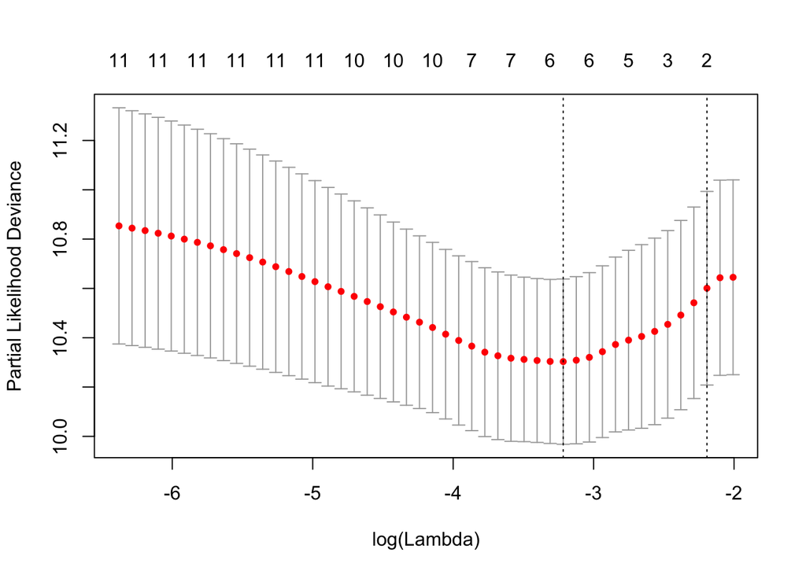

```r
cvfit = cv.glmnet(t(myexpr), Surv(mysurv$months,mysurv$status),
                  #10倍交叉验证，非必须限定条件，这篇文献有，其他文献大多没提
                  #nfold=10,
                  family = "cox"
                  )
plot(cvfit)
```

```r
#两个lambda值均可采用，具体lambda选值要根据自己实验设计而定。
#此处使用`lambda min`
cvfit$lambda.min #最佳lambda值
```

```
## [1] 0.0401029
```

```r
cvfit$lambda.1se #一倍SE内的更简洁的模型
```

```
## [1] 0.1115887
```

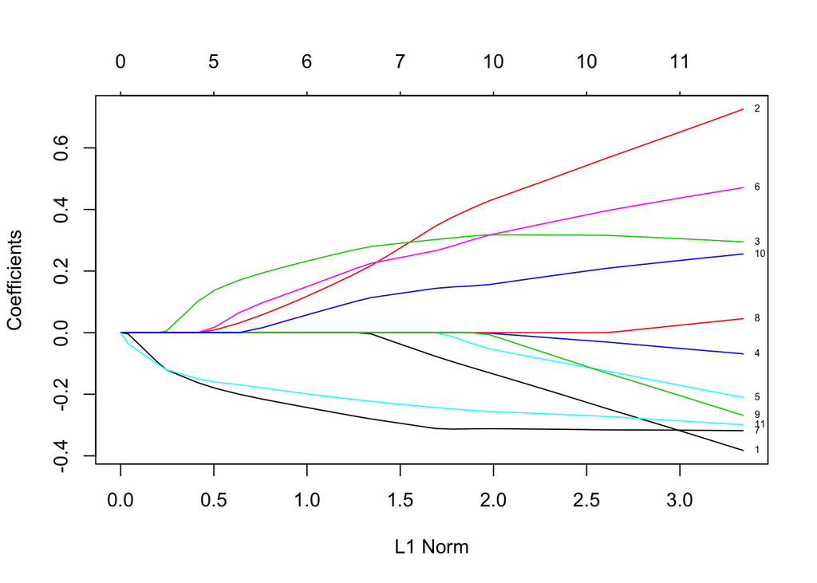

```r
fit <- glmnet(t(myexpr), Surv(mysurv$months,mysurv$status),
               family = "cox")

#用包自带的函数画图
plot(fit, label = TRUE)
```

### 修改画图函数

原函数打印序号，需要修改画图函数，改为打印基因名

如果基因太多，打印基因名也看不清。在右侧列出图例，这样看起来更清晰。

```r
#自定义颜色
mycol <- rep(c("#223D6C","#D20A13","#FFD121","#088247","#11AA4D","#58CDD9","#7A142C","#5D90BA","#431A3D","#91612D","#6E568C","#E0367A","#D8D155","#64495D","#7CC767"),2)

#设置x轴最大值
xmax <- 3.6

plotCoef_plus <- function (beta, norm, lambda, df, dev, label = FALSE, legend = FALSE, xvar = c("norm",
    "lambda", "dev"), xlab = iname, ylab = "Coefficients", ...)
{
    which = nonzeroCoef(beta)
    nwhich = length(which)
    switch(nwhich + 1, `0` = {
        warning("No plot produced since all coefficients zero")
        return()
    }, `1` = warning("1 or less nonzero coefficients; glmnet plot is not meaningful"))
    beta = as.matrix(beta[which, , drop = FALSE])
    xvar = match.arg(xvar)
    switch(xvar, norm = {
        index = if (missing(norm)) apply(abs(beta), 2, sum) else norm
        iname = "L1 Norm"
        approx.f = 1
    }, lambda = {
        index = log(lambda)
        iname = "Log Lambda"
        approx.f = 0
    }, dev = {
        index = dev
        iname = "Fraction Deviance Explained"
        approx.f = 1
    })
    dotlist = list(...)
    type = dotlist$type

    if (legend){
      #在右侧留出画图例的地方
      par(xpd = T, mar = par()$mar + c(0,0,0,6))
    }

    #修改bty，换个更好看的边框，还可以改成，o / n / 7 / l / c / u / ]
    if (is.null(type))
        matplot(index, t(beta), lty = 1, lwd = 2,
                xlab = xlab, ylab = ylab,
                xlim = c(0, xmax), #设置x轴最大值
                col = mycol,#线的颜色
                type = "l", cex.lab=1.2, cex.axis=1,
                bty="n", ...)#不画右边框
    else matplot(index, t(beta), lty = 1, lwd = 2,
                 xlab = xlab, ylab = ylab,
                 xlim = c(0, xmax),
                 col = mycol,
                 type = "l", cex.lab=1.2, cex.axis=1,
                 bty="n", ...)
    atdf = pretty(index)
    prettydf = approx(x = index, y = df, xout = atdf, rule = 2,
        method = "constant", f = approx.f)$y
    axis(3, at = atdf, labels = prettydf, tcl = NA)

    if (label) {
        nnz = length(which)
        xpos = max(index)
        pos = 4
        if (xvar == "lambda") {
            xpos = min(index)
            pos = 2
        }
        xpos = rep(xpos, nnz)
        ypos = beta[, ncol(beta)]

        #原函数打印序号，修改为打印基因名
        text(xpos, ypos, paste(rownames(myexpr)[which]),
             cex = 0.8, #基因名字体大小
             #基因名的颜色跟线一样
             col = mycol,
             #如果你不想要彩色的字，就用下面这行
             #col = "black",
             pos = pos)
    }
    if (legend) {
      #画图例
      legend("topright",
           inset=c(-0.12,0),#图例画到图外面
           legend = rownames(myexpr), #图例文字
           col = mycol, #图例线的颜色，与文字对应
           lwd = 3, #图例中线的粗细
           cex = 1, #图例字体大小
           bty = "n") #不显示图例边框
    }
    par(xpd=FALSE)
}

plot.glmnet_plus <- function (x, xvar = c("norm", "lambda", "dev"), label = FALSE, legend = FALSE,
    ...)
{
    xvar = match.arg(xvar)
    plotCoef_plus(x$beta, lambda = x$lambda, df = x$df, dev = x$dev.ratio,
        label = label, legend = legend, xvar = xvar, ...)
}
```

### 在线的旁边显示基因名

用修改后的函数画图

```r
pdf("lasso_name.pdf",width = 10,height = 8)
plot.glmnet_plus(fit, label = TRUE, #打印基因名
                 legend = FALSE) #不显示图例

#在图上画虚线
#你想用哪个cutoff，就在“v = ”写上相应的数字
#此处以lambda.min作为cutoff
abline(v = cvfit$lambda.min, lty = 3, #线的类型，可以改成0, 1, 2, 3, 4, 5, 6
       lwd = 2, #线的粗细
       col = "black") #线的颜色
dev.off()
```

[figure not shown]

### 以图例的形式展示基因名

```r
pdf("lasso_legend.pdf",width = 10,height = 8)
plot.glmnet_plus(fit, label = FALSE, #不打印基因名
                 legend = TRUE) #显示图例
abline(v = cvfit$lambda.min, lty=3,
       lwd = 2,
       col = "black")
dev.off()
```

[figure not shown]

### 输出选中的基因

输出选中的基因及其coefficient，这个coefficient跟lasso图中的纵坐标是一致的

```r
#在参数“s =”后面写cutoff
#此处选用lambda.min
coef.min = coef(cvfit, s = "lambda.min")
coef.min
```

```
## 11 x 1 sparse Matrix of class "dgCMatrix"
##                  1
## mir-1   .
## mir-2   0.14176270
## mir-3   0.24517752
## mir-4   .
## mir-5   .
## mir-6   0.16891098
## mir-7  -0.25267836
## mir-8   .
## mir-9   .
## mir-10  0.07239455
## mir-11 -0.20536133
```

```r
#提取选中的基因名
active.min = which(coef.min != 0)
geneids <- rownames(myexpr)[active.min]
geneids
```

```
## [1] "mir-2"  "mir-3"  "mir-6"  "mir-7"  "mir-10" "mir-11"
```

```r
#提取选中的基因对应的coefficient
index.min = coef.min[active.min]
index.min
```

```
## [1]  0.14176270  0.24517752  0.16891098 -0.25267836  0.07239455 -0.20536133
```

```r
#输出到文件
combine <- cbind(geneids, index.min)
write.csv(combine,"gene_index.csv")
```

### 输出用于nomogram作图的文件

将纳入signature的变量拟合成一个变量，作为nomogram的输入

```r
signature <- as.matrix(t(myexpr[geneids,])) %*% as.matrix(index.min)
summary(signature)
```

```
##        V1
##  Min.   :-0.97787
##  1st Qu.:-0.04258
##  Median : 0.24713
##  Mean   : 0.30006
##  3rd Qu.: 0.62175
##  Max.   : 2.15942
```

```r
colnames(signature)[1] <- "lasso"
row.names = row.names(myexpr)
write.table(signature,"lasso_output.txt",row.names = T, quote = F)
```